# a1_task2_walsh_shelby

Shelby Walsh

1/22/2021

# Looking at different planetary relationships

In this analysis, I will be using data from Google Earth Engine to look at the relationships between different environmental factors. The goal is to use Principle Component Analysis (PCA) to find if different factors are correlated, and if so, in what way. The variables I will be looking at are cropland cover, tree canopy cover, annual mean temperature and annual mean rainfall. Cropland cover is measured by the percent of a country’s land that is covered by cropland; tree canopy cover is the percentage of land covered by trees greater that 5 meters tall; annual mean temperature is the average annual temperature in degree Celcius; annual mean rainfall is the average mean rainfall in millimeters(mm).

#### Data sourced from Google Earth Engine: https://earthengine.google.com/

#### Citation: Gorelick, N., Hancher, M., Dixon, M., Ilyushchenko, S., Thau, D., & Moore, R. (2017). Google Earth Engine: Planetary-scale geospatial analysis for everyone. Remote Sensing of Environment.

```r
knitr::opts_chunk$set(echo = TRUE, message = FALSE, warning = FALSE)

library(tidyverse)
library(janitor)
library(here)
library(ggfortify)
library(readxl)
library(gghighlight)
library(lubridate)
library(plotly)
library(patchwork)
```

```r
# read in and clean Earth Engine data
world_env <- read_csv("world_env_vars.csv") %>%
  clean_names()

# Look at the relationships between cropland cover, tree canopy cover, annual mean temp and annual mean rainfall. Rename cariable to look nicer in the PCA biplot

world_env_pca <- world_env %>%
  select(cropland_cover, tree_canopy_cover, temp_mean_annual, rain_mean_annual) %>%
  rename(Annual.Mean.Rain = rain_mean_annual,
        Cropland.Cover = cropland_cover,
         Tree.Canopy.Cover = tree_canopy_cover ,
         Annual.Mean.Temp = temp_mean_annual ) %>%
  drop_na() %>%
  scale() %>%
  prcomp()

# Drop na's for variable in the PCA analysis
world_env_u <- world_env %>%
  drop_na(cropland_cover, tree_canopy_cover, temp_mean_annual, rain_mean_annual)

# Look at the rotations of each variable compared to the other 3 varibles
world_env_pca$rotation
```

```
##                          PC1        PC2         PC3         PC4
## Cropland.Cover     0.3845719 -0.5998638 -0.70158069  0.00724337
## Tree.Canopy.Cover -0.5497727 -0.5013754  0.13408392  0.65451829
## Annual.Mean.Temp  -0.4202515  0.5456440 -0.69475593  0.20730550
## Annual.Mean.Rain  -0.6109363 -0.3017596 -0.08438146 -0.72703354
```

```r
# Plot biplot so that arrows and labels are legible. Since we are looking at the world as a whole, do not colour code by country (trends weren't present)
world_pca_plot <- autoplot(world_env_pca,
         data = world_env_u,
         #shape = FALSE,
         loadings = TRUE,
         colour = "lightpink2",
         loadings.label = TRUE,
         loadings.colour = "black",
         loadings.label.colour = "black",
         loadings.label.vjust = -0.3,
         loadings.label.hjust = 1.15,
         loadings.label.size  = 4,
         loadings.label.face = "bold"
         ) +
  theme_minimal() +
  theme(legend.position = "none")
```

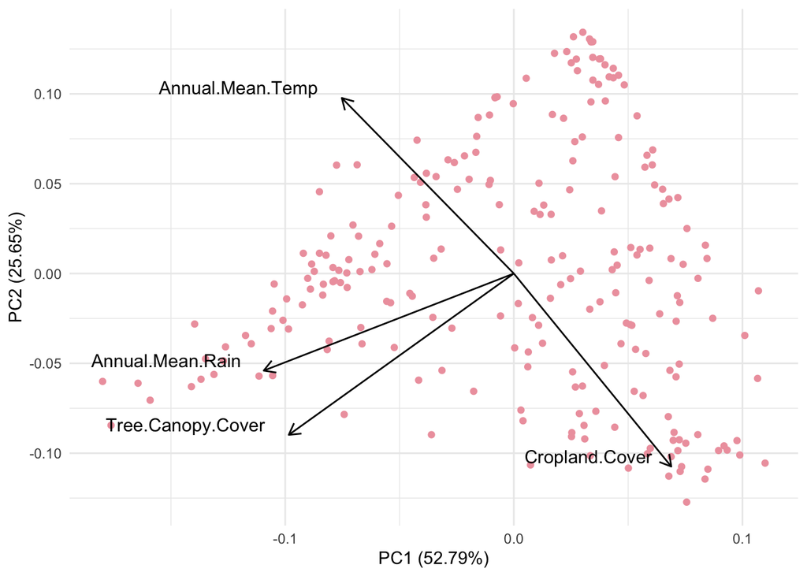

```r
world_pca_plot
```

## Global PCA Biplot Findings

- **Cropland cover is negatively correlated with annual mean temperature**
  - This was somewhat surprising since I would not associate extreme low temperatures with high cropland cover. However, it makes sense when thinking about dessert and extremely high temperatures not having the ability to sustain much cropland.
- **Tree Canopy Cover and Annual Mean Rainfall are highly positively correlated**
  - This matches my prediction that areas with higher rainfall would have higher tree canopy cover, as both temperate and tropical rainforests are located in areas with high rainfall.
- **Annual mean rainfall and tree canopy cover are not correlated to cropland cover or annual mean temperature**
  - This was surprising as I thought annual mean temperature and annual mean rainfall might have some positive correlation. I also thought that tree canopy cover and cropland cover would be negatively correlated as they are opposite forms of land cover.